# DataMining-HW1-Koçak

```python
import pandas as pd
import numpy as np
import matplotlib.pyplot as plt
import seaborn as sns
```

```python
df = pd.read_csv ('/Users/irembetulkocak/Desktop/datamininghw1/all_ticks_wide.csv')
df.head()
```

|  | timestamp | AEFES | AKBNK | AKSA | AKSEN | ALARK | ALBRK | ANACM | ARCLK | ASELS | ... | TTKOM | TUKAS | TUPRS | USAK | VAKBN | VESTL | YATAS | YKBNK | YUNSA | ZOREN |
| --- | --- | --- | --- | --- | --- | --- | --- | --- | --- | --- | --- | --- | --- | --- | --- | --- | --- | --- | --- | --- | --- |
| 0 | 2012-09-17T06:45:00Z | 22.3978 | 5.2084 | 1.7102 | 3.87 | 1.4683 | 1.1356 | 1.0634 | 6.9909 | 2.9948 | ... | 4.2639 | 0.96 | 29.8072 | 1.0382 | 3.8620 | 1.90 | 0.4172 | 2.5438 | 2.2619 | 0.7789 |
| 1 | 2012-09-17T07:00:00Z | 22.3978 | 5.1938 | 1.7066 | 3.86 | 1.4574 | 1.1275 | 1.0634 | 6.9259 | 2.9948 | ... | 4.2521 | 0.96 | 29.7393 | 1.0382 | 3.8529 | 1.90 | 0.4229 | 2.5266 | 2.2462 | 0.7789 |
| 2 | 2012-09-17T07:15:00Z | 22.3978 | 5.2084 | 1.7102 | NaN | 1.4610 | 1.1356 | 1.0679 | 6.9909 | 2.9855 | ... | 4.2521 | 0.97 | 29.6716 | 1.0463 | 3.8436 | 1.91 | 0.4229 | 2.5266 | 2.2566 | 0.7789 |
| 3 | 2012-09-17T07:30:00Z | 22.3978 | 5.1938 | 1.7102 | 3.86 | 1.4537 | 1.1275 | 1.0679 | 6.9584 | 2.9855 | ... | 4.2521 | 0.97 | 29.7393 | 1.0382 | 3.8529 | 1.91 | 0.4286 | 2.5324 | 2.2619 | 0.7860 |
| 4 | 2012-09-17T07:45:00Z | 22.5649 | 5.2084 | 1.7102 | 3.87 | 1.4574 | 1.1356 | 1.0725 | 6.9909 | 2.9760 | ... | 4.2521 | 0.97 | 29.8072 | 1.0382 | 3.8620 | 1.90 | 0.4286 | 2.5324 | 2.2619 | 0.7789 |

5 rows × 61 columns

```python
df.dropna()
```

|  | timestamp | AEFES | AKBNK | AKSA | AKSEN | ALARK | ALBRK | ANACM | ARCLK | ASELS | ... | TTKOM | TUKAS | TUPRS | USAK | VAKBN | VESTL | YATAS | YKBNK | YUNSA | ZOREN |
| --- | --- | --- | --- | --- | --- | --- | --- | --- | --- | --- | --- | --- | --- | --- | --- | --- | --- | --- | --- | --- | --- |
| 23955 | 2016-03-28T06:30:00Z | 19.0623 | 6.2904 | 7.1998 | 2.57 | 1.3966 | 1.4683 | 1.0096 | 16.9454 | 8.9773 | ... | 6.4287 | 1.62 | 53.7205 | 1.0301 | 4.3355 | 5.51 | 0.7286 | 2.5389 | 2.6332 | 1.3368 |
| 23983 | 2016-03-28T14:15:00Z | 18.8378 | 6.2510 | 7.3450 | 2.56 | 1.4006 | 1.4502 | 0.9990 | 17.0097 | 8.9478 | ... | 6.4287 | 1.63 | 53.6866 | 1.0220 | 4.3258 | 5.47 | 0.7286 | 2.5195 | 2.6332 | 1.3205 |
| 23984 | 2016-03-28T14:30:00Z | 18.7442 | 6.2510 | 7.3450 | 2.55 | 1.3966 | 1.4594 | 0.9990 | 16.9362 | 8.9330 | ... | 6.4095 | 1.63 | 53.6189 | 1.0220 | 4.3064 | 5.48 | 0.7257 | 2.5131 | 2.6332 | 1.3205 |
| 23985 | 2016-03-29T06:30:00Z | 18.7442 | 6.2904 | 7.3588 | 2.56 | 1.4127 | 1.4594 | 1.0043 | 16.9545 | 8.9823 | ... | 6.4287 | 1.63 | 53.8898 | 1.0301 | 4.3451 | 5.50 | 0.7286 | 2.5324 | 2.6428 | 1.3205 |
| 24013 | 2016-03-29T14:15:00Z | 18.9500 | 6.2432 | 7.3520 | 2.55 | 1.4287 | 1.4683 | 1.0256 | 17.1936 | 8.9478 | ... | 6.3230 | 1.62 | 53.7543 | 1.0301 | 4.3258 | 5.52 | 0.7229 | 2.5389 | 2.6907 | 1.3287 |
| ... | ... | ... | ... | ... | ... | ... | ... | ... | ... | ... | ... | ... | ... | ... | ... | ... | ... | ... | ... | ... | ... |
| 49975 | 2019-07-22T14:00:00Z | 20.3000 | 7.4700 | 9.0700 | 2.43 | 3.2100 | 1.1900 | 2.8300 | 20.1600 | 18.0300 | ... | 5.5100 | 4.30 | 129.2000 | 1.0300 | 4.7500 | 10.03 | 5.5000 | 2.7200 | 4.2300 | 1.1800 |
| 49976 | 2019-07-22T14:15:00Z | 20.4000 | 7.4600 | 9.0800 | 2.43 | 3.2100 | 1.2000 | 2.8200 | 20.2400 | 18.0400 | ... | 5.4900 | 4.30 | 129.4000 | 1.0400 | 4.7600 | 10.03 | 5.5000 | 2.7300 | 4.2300 | 1.1800 |
| 49977 | 2019-07-22T14:30:00Z | 20.6000 | 7.4900 | 9.1000 | 2.43 | 3.2000 | 1.2000 | 2.8300 | 20.2400 | 18.0400 | ... | 5.4700 | 4.31 | 129.0000 | 1.0300 | 4.7500 | 10.01 | 5.4900 | 2.7200 | 4.2400 | 1.1800 |
| 49978 | 2019-07-22T14:45:00Z | 20.5800 | 7.5200 | 9.0900 | 2.42 | 3.2000 | 1.1900 | 2.8400 | 20.1800 | 18.0600 | ... | 5.4600 | 4.29 | 128.6000 | 1.0300 | 4.7500 | 10.01 | 5.4700 | 2.7200 | 4.2400 | 1.1800 |
| 49979 | 2019-07-22T15:00:00Z | 20.4200 | 7.5300 | 9.1300 | 2.43 | 3.1800 | 1.2000 | 2.8300 | 20.1200 | 18.0300 | ... | 5.4700 | 4.27 | 129.1000 | 1.0400 | 4.7600 | 10.02 | 5.4600 | 2.7200 | 4.2300 | 1.1700 |

9228 rows × 61 columns

```python
stock_names = df.columns
print (stock_names)
```

```
Index(['timestamp', 'AEFES', 'AKBNK', 'AKSA', 'AKSEN', 'ALARK', 'ALBRK',
       'ANACM', 'ARCLK', 'ASELS', 'ASUZU', 'AYGAZ', 'BAGFS', 'BANVT', 'BRISA',
       'CCOLA', 'CEMAS', 'ECILC', 'EREGL', 'FROTO', 'GARAN', 'GOODY', 'GUBRF',
       'HALKB', 'ICBCT', 'ISCTR', 'ISDMR', 'ISFIN', 'ISYAT', 'KAREL', 'KARSN',
       'KCHOL', 'KRDMB', 'KRDMD', 'MGROS', 'OTKAR', 'PARSN', 'PETKM', 'PGSUS',
       'PRKME', 'SAHOL', 'SASA', 'SISE', 'SKBNK', 'SODA', 'TCELL', 'THYAO',
       'TKFEN', 'TOASO', 'TRKCM', 'TSKB', 'TTKOM', 'TUKAS', 'TUPRS', 'USAK',
       'VAKBN', 'VESTL', 'YATAS', 'YKBNK', 'YUNSA', 'ZOREN'],
      dtype='object')
```

```python
pd.set_option('display.max_columns', None)
print(df.describe())
```

```
              AEFES         AKBNK          AKSA         AKSEN         ALARK  \
count  48131.000000  49209.000000  48594.000000  48171.000000  48335.000000
mean      20.982235      6.473105      7.127504      3.183542      2.060859
std        2.494002      0.944955      2.710033      0.724332      0.575943
min        0.000100      0.000100      0.000100      0.000000      0.000100
25%       19.160500      5.850000      5.208800      2.670000      1.568900
50%       20.646500      6.305700      6.985300      2.930000      1.937600
75%       22.732000      6.932500      8.720000      3.750000      2.421400
max       28.509000      9.212400     15.118900      5.190000      3.514300

              ALBRK         ANACM         ARCLK         ASELS         ASUZU  \
count  46862.000000  48165.000000  49045.000000  48803.000000  48433.000000
mean       1.365549      1.672102     15.388088     13.432535      6.467033
std        0.167824      0.788365      4.531459      9.624246      2.201036
min        1.025500      0.000100      0.000100      0.000100      0.000100
25%        1.225100      1.047000     11.711100      4.940300      5.074800
50%        1.360200      1.259700     15.010000      9.275700      5.949600
75%        1.500000      2.402100     19.087700     22.756700      7.120000
max        2.190000      3.502100     26.427800     46.761600     15.280000

              AYGAZ         BAGFS         BANVT         BRISA         CCOLA  \
count  48119.000000  48650.000000  47951.000000  48937.000000  48749.000000
mean       8.101948     10.407127      7.628230      6.544896     36.890707
std        2.610402      3.618058      6.267278      1.295321      6.747213
min        0.000100      0.000100      0.000000      0.000100      0.000100
25%        5.951500      8.261750      2.590000      5.890000     31.978200
50%        7.723800     10.610000      3.710000      6.730000     34.821500
75%       10.269000     12.350000     11.930000      7.330000     42.049700
max       13.593500     38.435200     28.680000     10.327500     54.220800

              CEMAS         ECILC         EREGL         FROTO         GARAN  \
count  46394.000000  48492.000000  49173.000000  48995.000000  49308.000000
mean       1.209088      2.075865      4.179544     32.763693      7.899734
std        0.799981      0.973788      2.690731     14.732664      1.249637
min        0.000000      0.000100      0.000100      0.000100      0.000100
25%        0.700000      1.172300      2.181200     21.493800      7.015400
50%        0.870000      1.821400      3.036000     27.118200      7.654200
75%        1.500000      2.780900      6.758700     48.511600      8.678600
max        7.010000      4.227800     10.471000     65.419200     12.155400

```

[output cut: 64 more lines]

```
min        0.000100      0.650000      0.000100      0.000100      0.000100
25%        5.267300      1.060000     34.549100      0.957100      4.032200
50%        5.746400      1.530000     49.554200      1.050000      4.474200
75%        6.260000      2.130000     93.428700      1.370800      5.246000
max        7.350000      5.920000    139.293700      2.757800      7.581400

              VESTL         YATAS         YKBNK         YUNSA         ZOREN
count  48781.000000  46055.000000  49225.000000  45528.000000  48807.000000
mean       5.942711      2.434249      2.566327      4.079695      1.248124
std        2.830465      2.552377      0.422774      1.347020      0.311330
min        0.000000      0.000100      0.000100      0.000100      0.000100
25%        4.020000      0.388600      2.268200      3.006700      1.033800
50%        6.320000      0.965800      2.609300      4.107800      1.250000
75%        7.450000      4.230000      2.874000      4.720600      1.426500
max       14.540000     10.674800      3.958100      9.527500      2.443000
```

Data type for timestamp is not datetime so we adjust it to become datetime data.

```python
df['timestamp'] = pd.to_datetime(df['timestamp'])
df.set_index('timestamp', inplace=True)
```

```python
print(df.index.dtype)
```

```
datetime64[ns, UTC]
```

# Descriptive Analysis

Since we know the 5-number summary of each stock price, we will look at how their prices change over time. The line chart below, while too complicated and dirty, shows us that most stocks started from a real low point and continue that way until the end of our time. So I will look at the central tendency graph and pick 5 outstanding stocks and 5 stocks with lower prices.

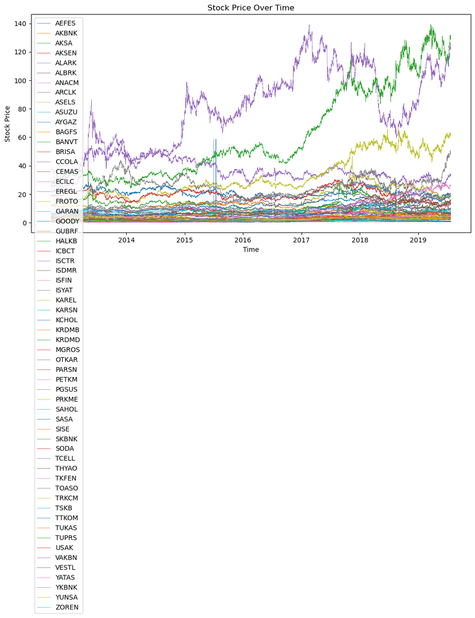

```python
plt.figure(figsize=(12, 6))
for stock_name in df.columns:
    plt.plot(df.index, df[stock_name], label=stock_name, linewidth=0.5)
plt.xlabel('Time')
plt.ylabel('Stock Price')
plt.legend()
plt.title('Stock Price Over Time')
plt.show()
```

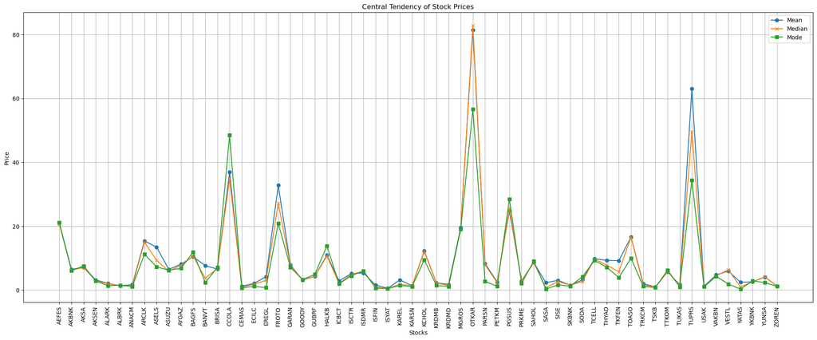

```python
plt.figure(figsize=(20, 8))
df.mean().plot(label='Mean', marker='o')
df.median().plot(label='Median', marker='x')
df.mode().iloc[0].plot(label='Mode', marker='s')
plt.xlabel('Stocks')
plt.ylabel('Price')
plt.title('Central Tendency of Stock Prices')
plt.legend()
plt.grid(True)
plt.tight_layout()
plt.xticks(ticks = range(len(df.columns)), labels = df.columns, rotation=90)
plt.show()
```

From the graph above, we can observe that CCOLA, FROTO, OTKAR, PGSUS, and TUPRS have the highest means, modes, and medians. We've also selected five stocks with lower measurements that may reveal interesting price changes over time: AEFES, ARCLK, HALKB, THYAO, and TCELL.

To display all the stock names in this plot, I had to rotate them, a task I hadn't done before, making it quite an achievement for me.

```
<function matplotlib.pyplot.show(close=None, block=None)>
```

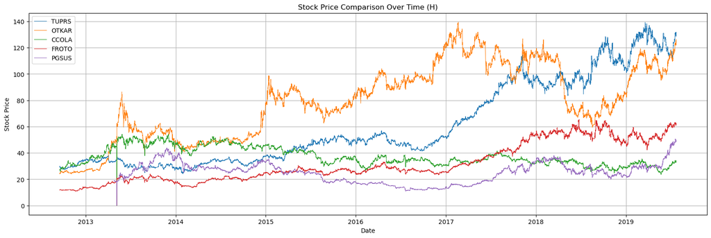

```python
plt.figure(figsize=(20, 6))
plt.plot (df.index, df ['TUPRS'], linewidth = 0.75, label = 'TUPRS')
plt.plot (df.index, df ['OTKAR'], linewidth = 0.75, label = 'OTKAR')
plt.plot (df.index, df ['CCOLA'], linewidth = 0.75, label = 'CCOLA')
plt.plot (df.index, df ['FROTO'], linewidth = 0.75, label = 'FROTO')
plt.plot (df.index, df ['PGSUS'], linewidth = 0.75, label = 'PGSUS')
plt.xlabel('Date')
plt.ylabel('Stock Price')
plt.title ('Stock Price Comparison Over Time (H)')
plt.legend()
plt.grid(True)
plt.show
```

We notice that OTKAR experiences more price spikes over time, while TUPRS shows a consistent upward price trend. Despite the higher mean and median of OTKAR, TUPRS appears to be a more consistent stock for investment.

```
<function matplotlib.pyplot.show(close=None, block=None)>
```

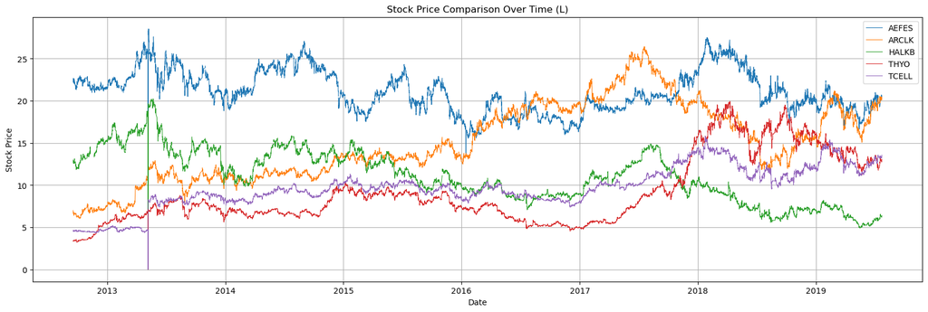

```python
plt.figure(figsize=(20, 6))
plt.plot (df.index, df ['AEFES'], linewidth = 0.75, label = 'AEFES')
plt.plot (df.index, df ['ARCLK'], linewidth = 0.75, label = 'ARCLK')
plt.plot (df.index, df ['HALKB'], linewidth = 0.75, label = 'HALKB')
plt.plot (df.index, df ['THYAO'], linewidth = 0.75, label = 'THYO')
plt.plot (df.index, df ['TCELL'], linewidth = 0.75, label = 'TCELL')
plt.xlabel('Date')
plt.ylabel('Stock Price')
plt.title ('Stock Price Comparison Over Time (L)')
plt.legend()
plt.grid(True)
plt.show
```

From the correlation matrix below, we can see that AEFES is one of the rare stocks that displays a positive correlation with HALKBK.

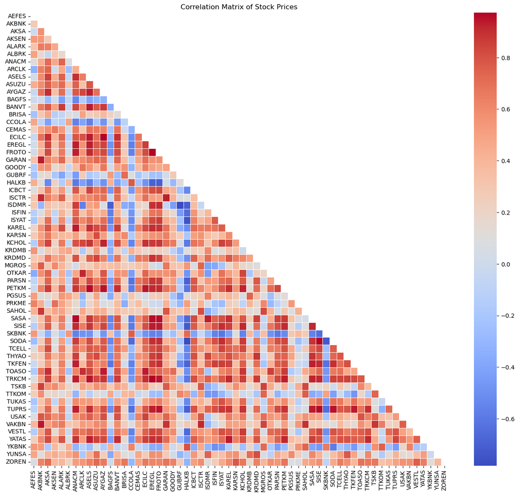

```python
correlation_matrix = df.corr()
mask = np.triu(np.ones_like(correlation_matrix, dtype=bool))
plt.figure(figsize=(16, 14))
sns.heatmap(correlation_matrix, annot=False, cmap='coolwarm', linewidths=0.5,  mask=mask)
plt.title('Correlation Matrix of Stock Prices')
plt.show()
```

Before we proceed to the pairwise comparison, we will examine the correlation between the stocks. I omit the upper triangle in this graph to have a more clear image since the number of stocks is already high.

We can observe a negative correlation, whether it's high or low, between HALKB and nearly all other stocks, with a particularly high one with TUPRS. Given the increasing trend in the price of TUPRS, it's likely that HALKB is experiencing a decreasing trend in its price.

```
<function matplotlib.pyplot.show(close=None, block=None)>
```

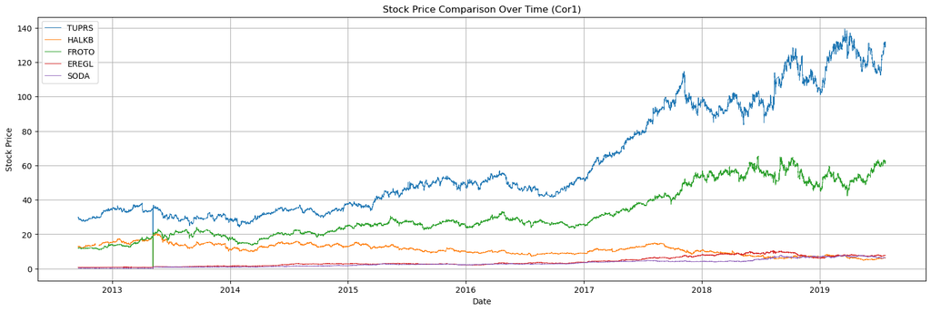

```python
plt.figure(figsize=(20, 6))
plt.plot (df.index, df ['TUPRS'], linewidth = 0.75, label = 'TUPRS')
plt.plot (df.index, df ['HALKB'], linewidth = 0.75, label = 'HALKB')
plt.plot (df.index, df ['FROTO'], linewidth = 0.75, label = 'FROTO')
plt.plot (df.index, df ['EREGL'], linewidth = 0.75, label = 'EREGL')
plt.plot (df.index, df ['SODA'], linewidth = 0.75, label = 'SODA')
plt.xlabel('Date')
plt.ylabel('Stock Price')
plt.title ('Stock Price Comparison Over Time (Cor1)')
plt.legend()
plt.grid(True)
plt.show
```

We can clearly see that in the year of 2017, all stock prices are increasing and contunie this increase after 2018, as well. However, HALKB start to decrease after the half of the 2017.

So, I will choose to analyze two stocks based on my initial instincts: TUPRS and OTKAR. I'll also examine two negatively correlated stocks, SODA and HALKB. Lastly, I'll focus on two similar stocks, THYAO and ARCLK, which exhibit similar trends. I will also look at the two most expensive stocks of KOÇ Group: TUPRS and FROTO.

# Moving Window Correlation

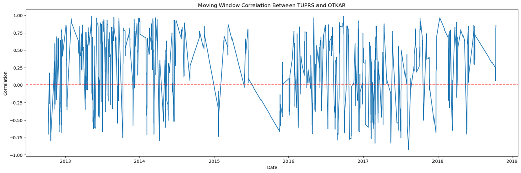

```python
stock1 = df['TUPRS']
stock2 = df['OTKAR']

window_size = 90 #3-months window

rolling_corr = stock1.rolling(window=window_size).corr(stock2)
rolling_corr = rolling_corr.dropna()
plt.figure(figsize=(20, 6))
plt.xlabel('Date')
plt.ylabel('Correlation')
plt.title('Moving Window Correlation Between TUPRS and OTKAR')
plt.plot(rolling_corr.index, rolling_corr)
plt.axhline(y=0, color='red', linestyle='--') #zero correlation line

plt.show()
```

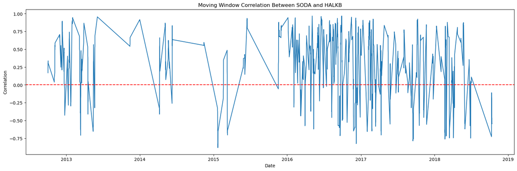

```python
stock3 = df['SODA']
stock4 = df['HALKB']

window_size = 90

rolling_corr = stock3.rolling(window=window_size).corr(stock4)
rolling_corr = rolling_corr.dropna()
plt.figure(figsize=(20, 6))
plt.xlabel('Date')
plt.ylabel('Correlation')
plt.title('Moving Window Correlation Between SODA and HALKB')
plt.plot(rolling_corr.index, rolling_corr)
plt.axhline(y=0, color='red', linestyle='--') #zero correlation line

plt.show()
```

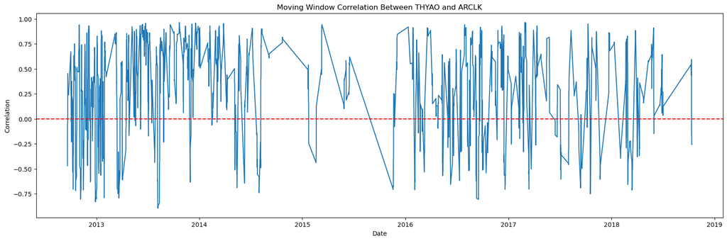

```python
stock5 = df['THYAO']
stock6 = df['ARCLK']

window_size = 90

rolling_corr = stock5.rolling(window=window_size).corr(stock6)
rolling_corr = rolling_corr.dropna()
plt.figure(figsize=(20, 6))
plt.xlabel('Date')
plt.ylabel('Correlation')
plt.title('Moving Window Correlation Between THYAO and ARCLK')
plt.plot(rolling_corr.index, rolling_corr)
plt.axhline(y=0, color='red', linestyle='--') #zero correlation line

plt.show()
```

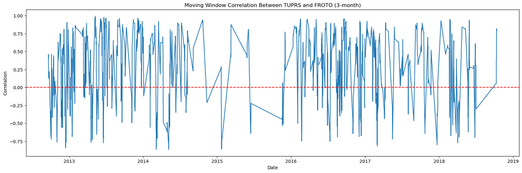

```python
stock7 = df['TUPRS']
stock8 = df['FROTO']

window_size = 90

rolling_corr = stock7.rolling(window=window_size).corr(stock8)
rolling_corr = rolling_corr.dropna()
plt.figure(figsize=(20, 6))
plt.xlabel('Date')
plt.ylabel('Correlation')
plt.title('Moving Window Correlation Between TUPRS and FROTO (3-month)')
plt.plot(rolling_corr.index, rolling_corr)
plt.axhline(y=0, color='red', linestyle='--') #zero correlation line

plt.show()
```

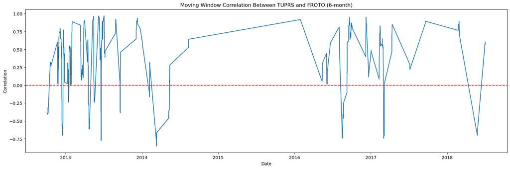

```python
window_size = 180

rolling_corr = stock7.rolling(window=window_size).corr(stock8)
rolling_corr = rolling_corr.dropna()
plt.figure(figsize=(20, 6))
plt.xlabel('Date')
plt.ylabel('Correlation')
plt.title('Moving Window Correlation Between TUPRS and FROTO (6-month)')
plt.plot(rolling_corr.index, rolling_corr)
plt.axhline(y=0, color='red', linestyle='--') #zero correlation line

plt.show()
```

## Moving Window Correlation Discussion

I adjusted the window size from one month to one year in the graphs and found that using a one-month window makes it difficult to interpret the values. On the other hand, extending the window to six months or a year results in the loss of many changes over time. So, I decided to stick with the 3-month window size.

Finally, I examine the correlation between FROTO and TUPRS to understand how two companies from the same group react to currency devaluation. To provide a broader perspective and demonstrate that a 6-month period can be misleading at first, I use two different window sizes to analyze the stock prices of these two companies.

It becomes evident that when we employ the 6-month window size, some negative movements in these two stock prices may be overlooked. However, it also allows us to see that there is generally a strong correlation between these two stocks, a pattern that persists even after the events of the year 2018.

# Principal Component Analysis

```python
from sklearn.decomposition import PCA
from sklearn.preprocessing import StandardScaler
```

```python
scaler = StandardScaler() # First we scale the data.
data_scaled = scaler.fit_transform(df)
```

```python
from sklearn.impute import SimpleImputer # I had the error that input has missing NaN data so I did imputer method to get rid of the missing data.
imp = SimpleImputer(missing_values=np.nan, strategy='mean')
data_scaled_imputed = imp.fit_transform(data_scaled)
```

```python
n_components = 4 # I adjust this number by doing experiments between 2 and 6. Keep 4. ( > 82% explained variation)
pca = PCA(n_components=n_components)
principal_components = pca.fit_transform(data_scaled_imputed)
eigenvalues = pca.explained_variance_
loadings = pd.DataFrame(pca.components_.T, columns=['PC1', 'PC2', 'PC3', 'PC4'], index = df.columns)
```

```python
print (pca.explained_variance_ratio_ )
```

```
[0.49440704 0.17319964 0.10618943 0.05031479]
```

We see that PC1 explains nearly half of the variance. This ratio decrease to %5 in PC4, so we can neglect it because 3 components can explain over 75% However, I would like to keep it since it does not make complex the model and increase the explained variance by 5 points.

```python
covariance_matrix = np.dot(loadings, loadings.T)
covariance_matrix = covariance_matrix * eigenvalues
```

[figure not shown]

```python
plt.figure(figsize=(5, 4))
sns.heatmap(covariance_matrix, annot=True, fmt=".3f", cmap="coolwarm", linewidths=0.5)
plt.title('Covariance Matrix Heatmap')
plt.show()
```

Covariances of all pairs of different components are zero, which tells us that these components are orthogonal to each other and captures different aspects of the data. It shows that PCA is working correctly on the data.

The diagonal values provide us with the eigenvalues for the principal components. The sum of the diagonal values gives us the overall variability. It's worth noting that PC1, represented as '0' in the heatmap, explains nearly half of the total variance, which was already obvious from explained_variance_ratio.

```python
print(loadings)
```

```
            PC1       PC2       PC3       PC4
AEFES -0.010580 -0.166200 -0.263168  0.024879
AKBNK -0.117748 -0.212250  0.075049 -0.103144
AKSA  -0.164168 -0.030486  0.069317  0.076500
AKSEN -0.074435 -0.159518 -0.150546 -0.189243
ALARK -0.139965 -0.080864 -0.111642 -0.160084
ALBRK -0.008276 -0.113372 -0.197956  0.248955
ANACM -0.168469  0.059489 -0.100526 -0.082598
ARCLK -0.126784 -0.029302  0.254853 -0.050817
ASELS -0.178046  0.006613  0.001303 -0.087705
ASUZU -0.152761 -0.088210 -0.128713  0.104481
AYGAZ -0.170347 -0.027914  0.089853 -0.066729
BAGFS  0.075920 -0.132281  0.139026  0.052050
BANVT -0.165309 -0.039445 -0.035231 -0.152178
BRISA -0.064381 -0.058005  0.209985  0.400038
CCOLA  0.096518 -0.156691 -0.131154  0.151579
CEMAS -0.115389 -0.052684 -0.071392 -0.166570
ECILC -0.171061 -0.034391  0.073675 -0.110917
EREGL -0.178386  0.063565 -0.035251  0.018634
FROTO -0.176396  0.070612 -0.038100  0.039272
GARAN -0.138418 -0.177507  0.012498 -0.009495
GOODY -0.106718 -0.056283  0.183608  0.050584
GUBRF  0.026441 -0.111295  0.272708  0.274224
HALKB  0.107098 -0.224522 -0.076987 -0.060501
ICBCT -0.138824  0.053661 -0.064476  0.009354
ISCTR -0.127698 -0.194671  0.023167 -0.047702
ISDMR -0.017276  0.035658 -0.078327  0.042637
ISFIN -0.104198  0.147630 -0.060136  0.064615
ISYAT -0.135940  0.112469  0.015909  0.073567
KAREL -0.165214  0.003847 -0.086153 -0.055140
KARSN -0.119257 -0.103878 -0.034654  0.289415
KCHOL -0.172928  0.015808  0.111822  0.011143
KRDMB -0.043744 -0.069703 -0.273080  0.149145
KRDMD -0.149872  0.017488 -0.146309  0.115916
MGROS -0.043587 -0.284971  0.034381 -0.085199
OTKAR -0.127356 -0.010214  0.245191  0.022006
PARSN -0.145044  0.082040 -0.007919 -0.023928
PETKM -0.180965  0.012493  0.037941 -0.064639
PGSUS -0.041628 -0.043196 -0.281653  0.113908
PRKME -0.020181 -0.194402 -0.207295 -0.222971
SAHOL -0.063889 -0.264127  0.059089 -0.022176
SASA  -0.165128  0.087401 -0.097048 -0.022196
SISE  -0.171833  0.097367  0.018065  0.025528
SKBNK  0.085718 -0.190358 -0.120968  0.213116
SODA  -0.155963  0.142925  0.033211  0.012527
TCELL -0.158765  0.012311 -0.005495  0.216592
THYAO -0.151315  0.054886 -0.166012  0.153157
TKFEN -0.152556  0.131257 -0.098228 -0.039504
TOASO -0.156432 -0.042569  0.176163 -0.047068
TRKCM -0.179823  0.023950 -0.047359  0.015147
TSKB  -0.084180 -0.252523  0.088922 -0.006623
TTKOM  0.010071 -0.270613  0.119445  0.106084
TUKAS -0.112760  0.064084  0.057347  0.090038
TUPRS -0.170805  0.098929 -0.015465 -0.034716
USAK  -0.130588 -0.138845  0.077678 -0.179399
VAKBN -0.099530 -0.250490  0.023689 -0.081949
VESTL -0.158809  0.037133  0.084793  0.132111
YATAS -0.165196 -0.015127 -0.074173 -0.040094
YKBNK  0.037198 -0.283729 -0.051179  0.005068
YUNSA -0.084366 -0.002389 -0.259987  0.196848
ZOREN -0.133207 -0.095940  0.073809  0.210226
```

We can refer to these components as latent variables since they can account for over 80% of the variance, which is a substantial amount. Initially, we had 60 observable variables, and now we have reduced them to just 4 latent variables (principal components) while explaining over 80% of the variance.

# Google Trends

## OTKAR & TUPRS

[figure not shown]

People often search for these companies using their formal names, not with their stock names, and the most commonly searched word with these formal names is 'investing'. So, I choose to search them in Google Trends with their formal names since there is no results for IST: OTKAR and does not show anything under this name.

However, the search trends do not align with their stock prices. For instance, TUPRS is more popular in Google Trends, despite having a significantly lower price than OTKAR. It shows that sometimes popularity of something in Google does not align with the value of that thing.

## HALKB

In this case, there are more results for HALKBANK in Google Trends compared to IST:HALKB. However, we need to consider that Halkbank has faced a negative public perception, particularly in the year 2018, which could potentially distort the data we are examining. For this reason, I choose to focus only on IST:HALKB.

When we examine the trend, we observe that the decreasing trend in Google Trend data is more dramatic than in the stock prices, but it generally aligns with them. The first noticeable declining trend appears in the stock prices is in 2016, and it is followed by a sharp decrease in the Google Trends search results.

[figure not shown]

## THYAO

I excluded the THY and Turkish Airlines keywords because they are most closely associated with terms like 'flight number' or 'airport.' However, with IST: THYAO, it is primarily searched alongside ASELS, TUPRS, and EREGL. As a result, I've decided to analyze them together in the same graph and will also include the stock price over time graph for these three. I excluded TUPRS since this stock has a solid domination in terms of popularity among all and make it harder to understand the relationship between others in the graph.

[figure not shown]

```
<function matplotlib.pyplot.show(close=None, block=None)>
```

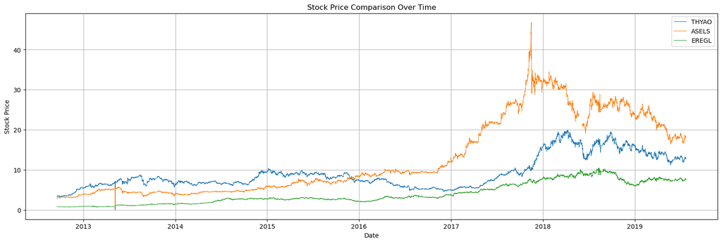

```python
plt.figure(figsize=(20, 6))
plt.plot (df.index, df ['THYAO'], linewidth = 0.75, label = 'THYAO')
plt.plot (df.index, df ['ASELS'], linewidth = 0.75, label = 'ASELS')
plt.plot (df.index, df ['EREGL'], linewidth = 0.75, label = 'EREGL')
plt.xlabel('Date')
plt.ylabel('Stock Price')
plt.title ('Stock Price Comparison Over Time')
plt.legend()
plt.grid(True)
plt.show
```

We observe a similar pattern with THYAO but on a smaller scale. There was a second peak in THYAO prices shortly after July 2018, in October 2018, coinciding with the highest search activity for this stock.

In the case of EREGL, there were no distinct peaks in Google Trends data, except for the last month of this dataset in July 2019. Notably, there were no dramatic shifts in the price of this stock during the same period. Therefore, the increased interest in this stock could be only a coincidence.

### Remark:

This was my first experience applying PCA to data using Python and I could not use the codes provided in the Moodle since it was in R. So, I had to search for and gather codes from various websites and forums.

It was very fun to play with this data, thank you for this homework!